# Introduction

In this assignment, I will build and compare classifiers for measuring the **sentiment of tweets related to COVID-19**.

The dataset I will work with is [publicly available in Kaggle](https://www.kaggle.com/datatattle/covid-19-nlp-text-classification) (and attached to the assignment for your convenience). Make sure to check its minimal Kaggle documentation before starting.

*Please note: this dataset should not but might contain content which could be considered as offensive.*

# Skeleton pipeline

My dataset contains tweets, including handlers, hashtags, URLs, etc. Set-up a **minimal pre-processing pipeline** for them (focus on the `OriginalTweet` column), possibly including:

- Tokenization
- Filtering
- Lemmatization/Stemming

```python
import pandas as pd
```

```python
df_train = pd.read_csv("data/Corona_NLP_train.csv", encoding = "latin1")
```

*We only use the `OriginalTweet` and `Sentiment` columns for this assignment.*

```python
from nltk.tokenize import TweetTokenizer
import nltk
import re

#Here I use a specific Twitter Tokenizer for tweets

listof_token_tweets = []

for OriginalTweet, Sentiment in zip(df_train.OriginalTweet, df_train.Sentiment):

    tok_tweet = TweetTokenizer().tokenize(OriginalTweet)

    listof_token_tweets.append((tok_tweet, Sentiment))

#store the list with respective pos for ppmi q4
text_pos = [(nltk.pos_tag(word, tagset = "universal"), sentiment) for word, sentiment in listof_token_tweets]
```

```python
#I now remove URls, hashtags, HTML Tags,
#Source: https://www.kaggle.com/garipurv/tweet-sentiment-analysis-lstm

REPLACE_URLS = re.compile(r'http[s]?://(?:[a-z]|[0-9]|[$-_@.&+]|[!*\(\),]|(?:%[0-9a-f][0-9a-f]))+')
REPLACE_HTML_TAGS = re.compile(r'<[^>]+>') #Removing non-words

#I decided not to include these as they mess with validation procedures:
#Specifically hashtag can be vital in identifying sentiments as seen on kaggle.

#REPLACE_HASH = re.compile(r'#(\w+)')
#REPLACE_AT = re.compile(r'@(\w+)')

#not filtering out numbers as these may have valuable correlation with sentiment:

#REPLACE_BY = re.compile(r"[^a-z0-9\-]")

stopwords = nltk.corpus.stopwords.words('english')

clean_tweets_list = []

for (tweet, sentiment) in listof_token_tweets:

    lemmatized_tweet = []

    for word in tweet:

        word = word.lower()
        word = REPLACE_HTML_TAGS.sub(' ', word)
        word = REPLACE_URLS.sub('', word)
        #word = REPLACE_HASH.sub('', word)
        #word = REPLACE_AT.sub('', word)
        #word = REPLACE_BY.sub(' ', word)

        if ((len(word) > 3) and (not word in stopwords)):

            lemma = nltk.WordNetLemmatizer().lemmatize(word)

            lemmatized_tweet.append(lemma)

    if lemmatized_tweet != []:
        y = " ".join(lemmatized_tweet)
        clean_tweets_list.append((y, sentiment))

#making list of words back into string

df = pd.DataFrame(clean_tweets_list, columns =['cleantweets', 'Sentiment'])
```

```python
df.head()
```

|  | cleantweets | Sentiment |
| --- | --- | --- |
| 0 | @menyrbie @phil_gahan @chrisitv | Neutral |
| 1 | advice talk neighbour family exchange phone nu... | Positive |
| 2 | coronavirus australia woolworth give elderly d... | Positive |
| 3 | food stock empty please panic enough food ever... | Positive |
| 4 | ready supermarket #covid19 outbreak paranoid f... | Extremely Negative |

```python
X = [i[0] for i in clean_tweets_list]
y = [i[1] for i in clean_tweets_list]
```

## Question 2 (5 points)

**Split your data into a train and a validation set**. You can use 85% for training and 15% for validation, or similar proportions. Remember to shuffle your data before splitting, specifying a seed to be able to replicate your results. - Random State Parameter.

```python
from sklearn.model_selection import train_test_split

#Random State Parameter is chosen to be 42..

X_train, X_test, y_train, y_test = train_test_split(X, y, test_size=0.15, random_state=42)
```

```python
#testing output

print(X[:1])
print(X_test[:1])
```

```
['@menyrbie @phil_gahan @chrisitv']
['consumer report offer tip clean reduce spread covid']
```

Here I write a function which, given as input a set of predictions and a set of ground truth labels, prints out a **classification report** including:

- Name of the method
- Accuracy
- Precision, recall and F1 measure
- An example of a correctly classified datapoint
- An example of a wrongly classified datapoint

```python
from sklearn.metrics import recall_score, precision_score, f1_score, accuracy_score

def class_report(method, X, pred, tru):

    print("Method: ", method)
    print("Accuracy: ", accuracy_score(tru, pred))
    print("Precision: ", precision_score(tru, pred, average = "weighted"))
    print("Recall: ", recall_score(tru, pred, average = "weighted"))
    print("F1 measure: ", f1_score(tru, pred, average = "weighted"))

    i = 0
    c = True
    w = True
    while c or w:
        if pred[i] == tru[i] and c == True:
            print("Correctly Classified Datapoint: ", X[i], "\nPredicted Sentiment: ", pred[i])
            break
        i+= 1

    i1 = 0
    c1 = True
    w1 = True
    while c1 or w1:
        if pred[i1] != tru[i1] and c1 == True:
            print("Falsely Classified Datapoint: ", X[i1], "\nPredicted Sentiment: ", pred[i1])
            break
        i1 += 1

#Average is used as classes are not equal.
```

# Classifying

An important first step when dealing with a real-world task is establishing a **solid baseline**. The baseline allows me to a) develop the first full pipeline for your task, and b) to have something to compare against when you develop more advanced models.

Here I pick a method to use as a baseline. *A good option might be a TF-IDF Logistic Regression*. Feel free to use scikit-learn or another library of choice. See [here](https://scikit-learn.org/stable/supervised_learning.html#supervised-learning) for more options.

I then use my classification report function and the validation set to report on the performance of your baseline.

```python
from sklearn.linear_model import LogisticRegression
from sklearn.feature_extraction.text import TfidfVectorizer, CountVectorizer

#idea from source: https://github.com/Giovanni1085/AUC_TMCI_2021/blob/main/notebooks/7_2_PyTorch.ipynb

tfidf_vectorizer = TfidfVectorizer() #create vectorizer
X_train_tfidf = tfidf_vectorizer.fit_transform(X_train) #transform train data into matrix representation
X_test_tfidf = tfidf_vectorizer.transform(X_test) #transform test data into vector
```

```python
Logistic_Reg = LogisticRegression(solver="lbfgs", max_iter=1000)
Logistic_Reg_fitted = Logistic_Reg.fit(X_train_tfidf, y_train)
```

```python
class_report("TF-IDF Logistic Regression", X_test, Logistic_Reg_fitted.predict(X_test_tfidf), y_test)
```

```
Method:  TF-IDF Logistic Regression
Accuracy:  0.5835358936963215
Precision:  0.5911589433381659
Recall:  0.5835358936963215
F1 measure:  0.5841419509143192
Correctly Classified Datapoint:  officially self isolating tomorrow went however would #covid_19 police still coughing like trooper look like dragged hedge backwards would clear supermarket went wonâ going
Predicted Sentiment:  Extremely Positive
Falsely Classified Datapoint:  consumer report offer tip clean reduce spread covid
Predicted Sentiment:  Extremely Positive
```

Next I **beat my baseline**.

How to beat the baseline? There are many ways:

1. You could have a better text representation (e.g., using PPMI instead of TF-IDF).
2. You can pick a more powerful model (e.g., random forests or SVMs).
3. You have to find good hyperparameters for your model, and not just use the default ones.

**Part 1.**

```python
#Using a count vectorizer as a text representation

from sklearn.feature_extraction.text import CountVectorizer

count_vect = CountVectorizer()
X_train_count = count_vect.fit_transform(X_train)
X_test_count = count_vect.transform(X_test)

Logistic_Reg2 = LogisticRegression(solver="lbfgs", max_iter=1000)
Logistic_Reg2_fitted = Logistic_Reg2.fit(X_train_count, y_train)
```

```python
class_report("Count-Vector & Logistic Regression", X_test, Logistic_Reg2_fitted.predict(X_test_count), y_test)
```

```
Method:  Count-Vector & Logistic Regression
Accuracy:  0.6208070004861449
Precision:  0.6213360593605793
Recall:  0.6208070004861449
F1 measure:  0.6198832877866215
Correctly Classified Datapoint:  consumer report offer tip clean reduce spread covid
Predicted Sentiment:  Positive
Falsely Classified Datapoint:  thanks stupid panic shopper buying everything like maniac elderly nothing parent like special need kid living paycheck paycheck cant find food family time shelf stocked raid #panicbuying #coronavirus
Predicted Sentiment:  Extremely Positive
```

**It improved the accuracy very slightly to the IDF Vectorizer!**

```python
#using a hashing vector as a text representation could be
#useful as it is more memory efficient than the count vector

from sklearn.linear_model import LogisticRegression
from sklearn.feature_extraction.text import HashingVectorizer

Hashing_Vectorizer = HashingVectorizer()
X_train_hash = Hashing_Vectorizer.fit_transform(X_train)
X_test_hash = Hashing_Vectorizer.transform(X_test)

Logistic_Reg2 = LogisticRegression(solver="lbfgs", max_iter=1000)
Logistic_Reg2.fit(X_train_hash, y_train)
```

```
LogisticRegression(max_iter=1000)
```

```python
class_report("Hashing Logistic Regression", X_test, Logistic_Reg2.predict(X_test_hash), y_test)
```

```
Method:  Hashing Logistic Regression
Accuracy:  0.5871009560849133
Precision:  0.5936077687386412
Recall:  0.5871009560849133
F1 measure:  0.5864707127745995
Correctly Classified Datapoint:  officially self isolating tomorrow went however would #covid_19 police still coughing like trooper look like dragged hedge backwards would clear supermarket went wonâ going
Predicted Sentiment:  Extremely Positive
Falsely Classified Datapoint:  consumer report offer tip clean reduce spread covid
Predicted Sentiment:  Extremely Positive
```

**Both do well and slightly better than the IDF vectorizer.**

I also tried PPMI, however do to space, readability and its low accuracy score of around 36%, I decided to leave this out. This is the approach I took:

1. Find PPMI Score for each word-context pair,
2. loop through test tweets,
3. for every word provide score and print total sum of ppmi score for every class,
4. highest ppmi score will provide class it corresponds to.

**Part 2.**

Here I will use the Count-Vector as it has enabled the best performance thus far

```python
from sklearn import svm, datasets
import time
import numpy as np
from sklearn.ensemble import BaggingClassifier, RandomForestClassifier
from sklearn import datasets
from sklearn.svm import SVC
```

**Multi-class classification, LinearSVC, Bagging Classifier: I did not use these as they ran too long.**

```python
start = time.time()

clf2 = RandomForestClassifier(min_samples_leaf=20) #initialize classifier
clf2_fitted = clf2.fit(X_train_count, y_train) #fit classifier

end = time.time()
```

```python
class_report("Random Forest", X_test, clf2_fitted.predict(X_test_count), y_test)
```

```
Method:  Random Forest
Accuracy:  0.45098039215686275
Precision:  0.588396440994591
Recall:  0.45098039215686275
F1 measure:  0.40927702018888407
Correctly Classified Datapoint:  consumer report offer tip clean reduce spread covid
Predicted Sentiment:  Positive
Falsely Classified Datapoint:  stabilitech's covid vaccine intended delivered disruptive thermally stable capsule safe efficacious self-administered vaccine capsule that's inexpensive produce developed week thermally stable posted direct consumer
Predicted Sentiment:  Positive
```

**Part 3:** Fine tuning parameters using

```python
from sklearn.model_selection import GridSearchCV

#Originally I had min_samples_leaf=20 which provided a result of 0.46
#I tried Grid Search to see whether the classification would improve

params = {"min_samples_leaf": [20],
          'criterion': ['gini'],
             'max_depth': [None],
             'max_features': ['auto'],
             'max_leaf_nodes': [None],
             'max_samples': [None],
             'min_impurity_decrease': [0.0],
             'min_impurity_split': [None],
             'min_samples_leaf': [20],
             'min_samples_split': [2],
             'min_weight_fraction_leaf': [0.0],
             "bootstrap": [True, False],
         }

clf_grid = GridSearchCV(estimator=clf2_fitted, param_grid=params, scoring="accuracy")
clf_grid_fitted = clf_grid.fit(X_train_count, y_train)
```

we can also perform a class_report on the grid fitted version for fun

```python
class_report("GridSearch", X_test, clf_grid_fitted.predict(X_test_count), y_test)
```

```
Method:  GridSearch
Accuracy:  0.48792740236590504
Precision:  0.5825196341870127
Recall:  0.48792740236590504
F1 measure:  0.45357019288287154
Correctly Classified Datapoint:  consumer report offer tip clean reduce spread covid
Predicted Sentiment:  Positive
Falsely Classified Datapoint:  stabilitech's covid vaccine intended delivered disruptive thermally stable capsule safe efficacious self-administered vaccine capsule that's inexpensive produce developed week thermally stable posted direct consumer
Predicted Sentiment:  Positive
```

Lets see what the best parameters are:

```python
clf_grid_fitted.best_estimator_
```

```
RandomForestClassifier(bootstrap=False, min_samples_leaf=20)
```

I think Im going to change the bootstrap to false as recommended but remove the leaf samples to see what happens

```python
start = time.time()

clf3 = RandomForestClassifier(bootstrap=False)
clf3_fitted = clf3.fit(X_train_count, y_train)

end = time.time()
```

```python
class_report("Random Forest #2", X_test, clf3_fitted.predict(X_test_count), y_test)
```

```
Method:  Random Forest #2
Accuracy:  0.576729865499919
Precision:  0.6015927540713232
Recall:  0.576729865499919
F1 measure:  0.5691413287214105
Correctly Classified Datapoint:  consumer report offer tip clean reduce spread covid
Predicted Sentiment:  Positive
Falsely Classified Datapoint:  stabilitech's covid vaccine intended delivered disruptive thermally stable capsule safe efficacious self-administered vaccine capsule that's inexpensive produce developed week thermally stable posted direct consumer
Predicted Sentiment:  Positive
```

Performs much better with minimal tuning!

```python
clf_grid2 = GridSearchCV(estimator=clf3_fitted, param_grid=params, scoring="accuracy")
clf_grid_fitted2 = clf_grid.fit(X_train_count, y_train)

class_report("GridSearch #2", X_test, clf_grid_fitted2.predict(X_test_count), y_test)
```

```
Method:  GridSearch #2
Accuracy:  0.4890617403986388
Precision:  0.5798244884083952
Recall:  0.4890617403986388
F1 measure:  0.4575177996467031
Correctly Classified Datapoint:  consumer report offer tip clean reduce spread covid
Predicted Sentiment:  Positive
Falsely Classified Datapoint:  stabilitech's covid vaccine intended delivered disruptive thermally stable capsule safe efficacious self-administered vaccine capsule that's inexpensive produce developed week thermally stable posted direct consumer
Predicted Sentiment:  Positive
```

Here I Design, develop and train a (simple!) **neural network-based classifier** for this task, using scikit-learn. The classifier can have the structure that you prefer, just make sure to motivate your choices. If in doubt, try with a bag of embeddings classifier.

*Note: an NN-based classifier with scikit-learn yields 5 points max; one with PyTorch yields 10 points max; one with PyTorch and pre-trained embeddings yields 15 points max.*

Use your classification report function and the validation set to report on the performance of your baseline. *Pay attention: the validation data only needs to be transformed, and must not be used to fit any transformation. For example, if you have used a TF-IDF vectorizer by fitting it to your train data and then transformed it, use the same fitted vectorizer to transform your validation data.*s

**NN-based classifier using Scikit-learn**

```python
from sklearn.neural_network import MLPClassifier
from sklearn.datasets import make_classification

#For starters I want to train a simple MLP Classifier with maximum iterations so it does not run too long...

clf_skl = MLPClassifier(random_state=1, max_iter=300).fit(X_train_count, y_train)

class_report("NN-based-Classifier", X_test, clf_skl.predict(X_test_count), y_test)
```

```
Method:  NN-based-Classifier
Accuracy:  0.574623237724842
Precision:  0.5755819884175929
Recall:  0.574623237724842
F1 measure:  0.575036648663053
Correctly Classified Datapoint:  consumer report offer tip clean reduce spread covid
Predicted Sentiment:  Positive
Falsely Classified Datapoint:  thanks stupid panic shopper buying everything like maniac elderly nothing parent like special need kid living paycheck paycheck cant find food family time shelf stocked raid #panicbuying #coronavirus
Predicted Sentiment:  Extremely Positive
```

I tried training a **NN using Sequential**, following the approach outlined here: https://www.tensorflow.org/tutorials/structured_data/feature_columns, where the feature column corresponds to the count-vectorized version of my training data.

**For pretrained models I then attempted to use Word2Vec using following source:**

https://towardsdatascience.com/another-twitter-sentiment-analysis-with-python-part-11-cnn-word2vec-41f5e28eda74

**Sadly, Im in a place where there is no good wifi, therefore I was unable to run this!**

# Evaluating my classifiers

## Question 7 (10 points)

Here I:

- Report the accuracy of each classifier, as well as its precision, recall and F1 score.
- Plot a [confusion matrix](https://scikit-learn.org/stable/auto_examples/model_selection/plot_confusion_matrix.html) for your best classifier.
- Briefly discuss my results.

```python
df_test.head()
```

|  | UserName | ScreenName | Location | TweetAt | OriginalTweet | Sentiment |
| --- | --- | --- | --- | --- | --- | --- |
| 0 | 1 | 44953 | NYC | 02-03-2020 | TRENDING: New Yorkers encounter empty supermar... | Extremely Negative |
| 1 | 2 | 44954 | Seattle, WA | 02-03-2020 | When I couldn't find hand sanitizer at Fred Me... | Positive |
| 2 | 3 | 44955 | NaN | 02-03-2020 | Find out how you can protect yourself and love... | Extremely Positive |
| 3 | 4 | 44956 | Chicagoland | 02-03-2020 | #Panic buying hits #NewYork City as anxious sh... | Negative |
| 4 | 5 | 44957 | Melbourne, Victoria | 03-03-2020 | #toiletpaper #dunnypaper #coronavirus #coronav... | Neutral |

```python
# tokenization, filtering, lemmatization for test data

from nltk.tokenize import TweetTokenizer
import nltk
import re

listof_token_tweets1 = []

for OriginalTweet, Sentiment in zip(df_test.OriginalTweet, df_test.Sentiment):

    tok_tweet = TweetTokenizer().tokenize(OriginalTweet)

    listof_token_tweets1.append((tok_tweet, Sentiment))

REPLACE_URLS = re.compile(r'http[s]?://(?:[a-z]|[0-9]|[$-_@.&+]|[!*\(\),]|(?:%[0-9a-f][0-9a-f]))+')
REPLACE_HTML_TAGS = re.compile(r'<[^>]+>') #Removing non-words

stopwords = nltk.corpus.stopwords.words('english')

clean_tweets_list1 = []

for (tweet, sentiment) in listof_token_tweets1:

    lemmatized_tweet = []

    for word in tweet:

        word = word.lower()
        word = REPLACE_HTML_TAGS.sub(' ', word)
        word = REPLACE_URLS.sub('', word)

        if ((len(word) > 3) and (not word in stopwords)):

            lemma = nltk.WordNetLemmatizer().lemmatize(word)

            lemmatized_tweet.append(lemma)

    if lemmatized_tweet != []:
        y = " ".join(lemmatized_tweet)
        clean_tweets_list1.append((y, sentiment))
```

```python
X_final_test = [i[0] for i in clean_tweets_list1]
y_final_test = [i[1] for i in clean_tweets_list1]
```

```python
from sklearn.feature_extraction.text import CountVectorizer

from sklearn.linear_model import LogisticRegression
from sklearn.feature_extraction.text import TfidfVectorizer, CountVectorizer

#idea from source: https://github.com/Giovanni1085/AUC_TMCI_2021/blob/main/notebooks/7_2_PyTorch.ipynb

from sklearn.feature_extraction.text import CountVectorizer
X_test_final_count = count_vect.transform(X_final_test)
X_test_final_tfidf = tfidf_vectorizer.transform(X_final_test) #transform test data into vector
```

```python
class_report("TF-IDF Logistic Regression with test file", X_final_test, Logistic_Reg_fitted.predict(X_test_final_tfidf), y_final_test)
class_report("Count-Vector & Logistic Regression with test file", X_final_test, Logistic_Reg2_fitted.predict(X_test_final_count), y_final_test)
class_report("Random Forest with test file", X_final_test, clf2_fitted.predict(X_test_final_count), y_final_test)
class_report("Random Forest #2 with test file", X_final_test, clf3_fitted.predict(X_test_final_count), y_final_test)
class_report("NN-based-Classifier with test file", X_final_test, clf_skl.predict(X_test_final_count), y_final_test)
```

```
Method:  TF-IDF Logistic Regression with test file
Accuracy:  0.5429173249078463
Precision:  0.5568422477361251
Recall:  0.5429173249078463
F1 measure:  0.5428348237641537
Correctly Classified Datapoint:  find hand sanitizer fred meyer turned #amazon 114.97 pack purell check #coronavirus concern driving price
Predicted Sentiment:  Positive
Falsely Classified Datapoint:  trending yorkers encounter empty supermarket shelf pictured wegmans brooklyn sold-out online grocer foodkick maxdelivery #coronavirus-fearing shopper stock
Predicted Sentiment:  Neutral
Method:  Count-Vector & Logistic Regression with test file
Accuracy:  0.5716166403370195
Precision:  0.5750507601594255
Recall:  0.5716166403370195
F1 measure:  0.5712758668202667
Correctly Classified Datapoint:  find hand sanitizer fred meyer turned #amazon 114.97 pack purell check #coronavirus concern driving price
Predicted Sentiment:  Positive
Falsely Classified Datapoint:  trending yorkers encounter empty supermarket shelf pictured wegmans brooklyn sold-out online grocer foodkick maxdelivery #coronavirus-fearing shopper stock
Predicted Sentiment:  Neutral
Method:  Random Forest with test file
Accuracy:  0.40784623486045285
Precision:  0.576021932561517
Recall:  0.40784623486045285
F1 measure:  0.36095094400147165
Correctly Classified Datapoint:  find hand sanitizer fred meyer turned #amazon 114.97 pack purell check #coronavirus concern driving price
Predicted Sentiment:  Positive
Falsely Classified Datapoint:  trending yorkers encounter empty supermarket shelf pictured wegmans brooklyn sold-out online grocer foodkick maxdelivery #coronavirus-fearing shopper stock
Predicted Sentiment:  Negative
Method:  Random Forest #2 with test file
Accuracy:  0.5055292259083728
Precision:  0.5371409990622036
Recall:  0.5055292259083728
F1 measure:  0.4968638618487487
Correctly Classified Datapoint:  find hand sanitizer fred meyer turned #amazon 114.97 pack purell check #coronavirus concern driving price
Predicted Sentiment:  Positive
Falsely Classified Datapoint:  trending yorkers encounter empty supermarket shelf pictured wegmans brooklyn sold-out online grocer foodkick maxdelivery #coronavirus-fearing shopper stock
Predicted Sentiment:  Negative
Method:  NN-based-Classifier with test file
Accuracy:  0.5297525013164823
Precision:  0.533839297157314
Recall:  0.5297525013164823
F1 measure:  0.5306246123022266
Correctly Classified Datapoint:  find hand sanitizer fred meyer turned #amazon 114.97 pack purell check #coronavirus concern driving price
Predicted Sentiment:  Positive
Falsely Classified Datapoint:  trending yorkers encounter empty supermarket shelf pictured wegmans brooklyn sold-out online grocer foodkick maxdelivery #coronavirus-fearing shopper stock
Predicted Sentiment:  Neutral
```

Most Models perform as expected, however I would have expected the Random Forrest Classifier and the neural network based classifier to do better!

```python
#8.1 confusion matrix from Source: https://github.com/Giovanni1085/AUC_TMCI_2021/blob/main/notebooks/8_1_NER.ipynb

def plot_confusion_matrix(test_labels, test_predictions, label_vocab):
    # we take all label strings
    labels = label_vocab

    # calculate the confusion matrix and normalize it
    cm = metrics.confusion_matrix(test_labels, test_predictions, labels=labels)
    cm = cm.astype('float') / (cm.sum(axis=1)[:, np.newaxis] + 1) # we add 1 to avoid division by zero

    # plot the confusion matrix using seaborn heatmap
    sns_heatmap = sns.heatmap(
        cm,
        cmap='RdYlGn_r',
        square=True,
        vmin=0,
        vmax=1)

    # beautify the plot so that it has better readability
    plt.ylim(0, len(labels) + 0.5)
    plt.ylim(0, len(labels) + 0.5)
    plt.xlabel('Predicted values', labelpad=20)
    plt.ylabel('True values')

    sns_heatmap.set_yticklabels(labels, rotation=0)
    sns_heatmap.set_xticklabels(labels, rotation=45, horizontalalignment='right')

    plt.show()
```

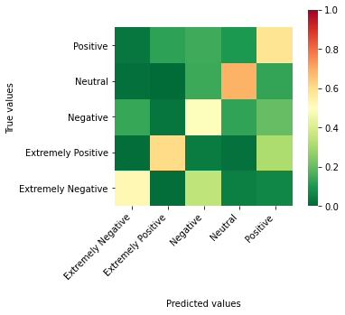

```python
from sklearn import metrics
import seaborn as sns

targets = ["Extremely Negative", "Extremely Positive", "Negative", "Neutral", "Positive"]
plot_confusion_matrix(y_final_test, Logistic_Reg2.predict(X_test_final_count), targets)
```

Now Im going to do some evaluating:

- I Select two (or more) of your classifiers which have somewhat similar results on your validation data. Make sure to select two methods which do not take too long to run.
- Merge your train and validation data, and implement a function to shuffle and sample a % of datapoints (with labels) from it.
- Iterate 5-10 times the following steps:
  - Shuffle and sample 80% of your training datapoints.
  - Train instances of the two classifiers on the same 80% sample.
  - Assess their accuracy on the test dataset and store these results (into two separate lists for each classifier).
- Perform a Wilcoxon test on these results and discuss whether the two classifiers are significantly different on this task and dataset.

```python
from sklearn.metrics import recall_score, precision_score, f1_score, accuracy_score
from sklearn.feature_extraction.text import CountVectorizer
from sklearn.feature_extraction.text import TfidfVectorizer, CountVectorizer


X1 = [i[0] for i in clean_tweets_list]
y1 = [i[1] for i in clean_tweets_list]

listn1 = []
listn2 = []

for i in range(10):

    X_train1, X_test1, y_train1, y_test1 = train_test_split(X, y, test_size=0.20, random_state=i)

    count_vect = CountVectorizer()
    X_train_count_final1 = count_vect.fit_transform(X_train1)
    X_test_count_final1 = count_vect.transform(X_test1)

    #logreg classifier
    final_logreg_fitted = Logistic_Reg2.fit(X_train_count_final1, y_train1)

    #optimized random forrest classifier
    final_clf3_fitted = clf3.fit(X_train_count_final1, y_train1)

    accuracy1 = accuracy_score(y_test1, final_logreg_fitted.predict(X_test_count_final1))
    accuracy2 = accuracy_score(y_test1, final_clf3_fitted.predict(X_test_count_final1))

    listn1.append(accuracy1)
    listn2.append(accuracy2)
```

[output not shown]

```python
print(listn1)
```

```
[0.5972289742343219, 0.5999027710257657, 0.5986874088478367, 0.6007535245503159, 0.5973505104521147, 0.5930967428293632, 0.5975935828877005, 0.5975935828877005, 0.5989304812834224, 0.6088964511424404]
```

```python
print(listn2)
```

```
[0.5574866310160428, 0.5653864851725814, 0.5578512396694215, 0.5653864851725814, 0.5548128342245989, 0.5567574137092853, 0.5589450656295576, 0.5574866310160428, 0.5685464268351968, 0.5600388915896938]
```

**Wilcoxon Test**

```python
from scipy.stats import wilcoxon

difference = []

for i1, i2 in zip(listn1, listn2):
    difference.append(i1-i2)

w, p = wilcoxon(difference)

print("p-value =", p)
```

```
p-value = 0.001953125
```

**Since the value is so low the null hypothesis can be rejected and the values are significantly different from a mathematical standpoint. Where the linreg models accuracy scores are evidently higher, the two lists dont look very different at a first glance.**